# StockResearch

Gabriel Foix

2021-03-16

Buy Quality at the a good momentum and get rid of the fishy stocks on time. That's all.

### Define candidates

#### Download Key Stats

```r
KeyStatistics.list <- YHFinR::getYFKeyStatistics(Candidates.df$Ticker)
```

[output not shown]

[output not shown]

[output not shown]

[output not shown]

[output not shown]

[output not shown]

[output not shown]

[output not shown]

[output not shown]

[output not shown]

[output not shown]

[output not shown]

[output not shown]

[output not shown]

[output not shown]

[output not shown]

[output not shown]

[output not shown]

[output not shown]

```
## Wrong ticker: FCA.MI
```

[output not shown]

[output not shown]

[output not shown]

[output not shown]

[output not shown]

[output not shown]

[output not shown]

[output not shown]

[output not shown]

[output not shown]

[output not shown]

[output not shown]

[output not shown]

[output not shown]

[output not shown]

[output not shown]

[output not shown]

[output not shown]

[output not shown]

[output not shown]

[output not shown]

[output not shown]

[output not shown]

```
## Wrong ticker: UBI.MI
```

[output not shown]

[output not shown]

[output not shown]

```r
# Save temp in case
remove("KeyStatistics.list.tmp.rds")
saveRDS(KeyStatistics.list, "KeyStatistics.list.tmp.rds")
# KeyStatistics.list <- readRDS("KeyStatistics.list.tmp.rds")
```

Filter by EV & EPS

#### Download Historical Data

Download only stocks not filtered previously Filter by historical data < 1 year

#### Download Financiall Basics

### Factor 1: Quality

1. Healthy debts: A company shoud generate cash in order to repay its debt. The **Free Cash Flow to Debt** ratio is a good indicator of how quick a company pays back its debt. The lower this ratio the better.

FCF2D = $\frac{Debt}{Free Cash Flow}$

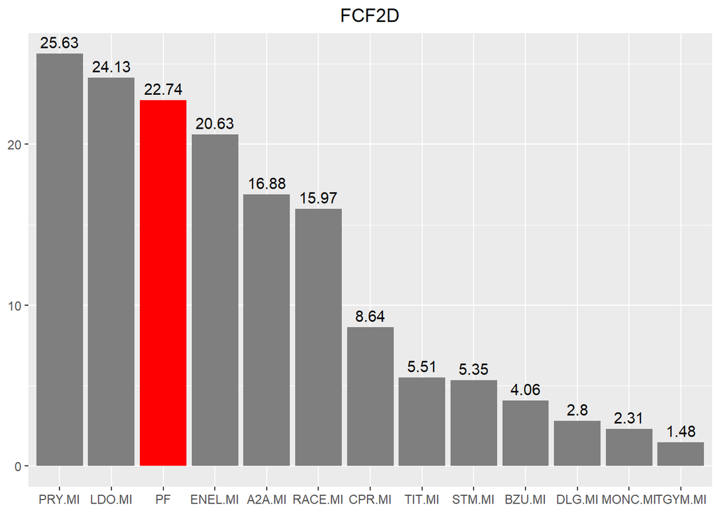

2. Profitability: ROA

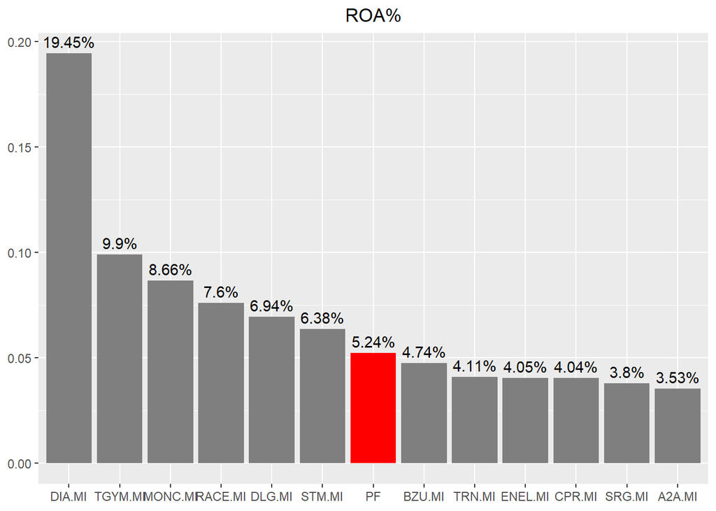

3. High Margin: We look for companies that generate free cash flow compare to its price. The **Free Cash Flow to Entreprise Value** ratio tells us how many years of cash flow would be needed to the return the 100% of the investment. Again, the lower, the better. Values bellow 1 would mean "free lunch".

FCF2EV = $\frac{EV}{Free Cash Flow}$

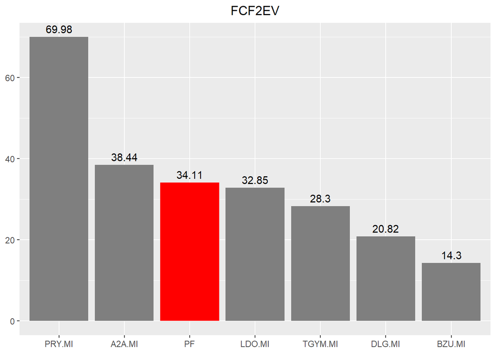

### Value touch

Filter out stocks with PER > 40

Report Candidates

Filter Summary

| Filter | NStocks |
| --- | --- |
| Initial | 45 |
| ROA | 18 |
| FCF | 18 |
| Hist1Y | 37 |
| PER | 18 |

### Factor 2: Momentum

Don't hold onto a stock simply because it is high quality. So called quality stocks have cycles too. Stan Weinstein (page 177)

Generic Intermediate-Term Momentum Based on Gray-Vogel (page 80)

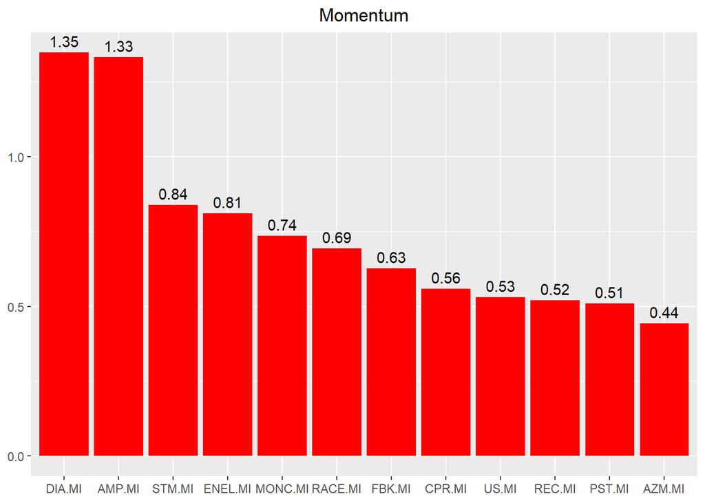

### Factor 3: Timing Signal

Sell Signal - Pr < 1% SMA 30 weeks and slope negative (< -0.2)  
Buy Signal - 109% * SMA30 < Pr > SMA 30 and slope positive (> 0.2)  
Hold Signal - Neither Buy nor Sell

#### Calc Market Cap

Using free float shares

### Summary

Summary

| Ticker | Signal | Quality | Momentum | Final_rank | PER | MCap |
| --- | --- | --- | --- | --- | --- | --- |
| DIA.MI | HOLD | 18.0 | 18 | 18.0 | 38.114965 | NA |
| STM.MI | BUY | 16.0 | 17 | 17.0 | 25.808333 | 20222295344 |
| FBK.MI | HOLD | 11.5 | 13 | 14.0 | 25.845323 | NA |
| ENEL.MI | HOLD | 7.0 | 16 | 13.0 | 19.497619 | 63598807869 |
| US.MI | HOLD | 10.0 | 11 | 11.5 | 8.701389 | NA |
| DLG.MI | HOLD | 11.5 | 9 | 10.0 | 25.455905 | 1581800381 |
| BGN.MI | HOLD | 13.0 | 7 | 9.0 | 12.713440 | NA |
| TGYM.MI | HOLD | 15.0 | 3 | 8.0 | 31.918238 | 881779491 |
| TRN.MI | HOLD | 5.5 | 10 | 7.0 | 16.264935 | 8698473280 |
| BZU.MI | HOLD | 8.0 | 5 | 6.0 | 9.832599 | 2909448498 |
| SRG.MI | HOLD | 4.0 | 8 | 5.0 | 13.969041 | 9197594268 |
| A2A.MI | HOLD | 3.0 | 4 | 3.5 | 12.982609 | 2256667516 |
| PRY.MI | HOLD | 1.0 | 6 | 3.5 | 37.470588 | 6174540006 |
| TIT.MI | HOLD | 5.5 | 1 | 2.0 | 1.325656 | 7041294392 |
| LDO.MI | HOLD | 2.0 | 2 | 1.0 | 18.501193 | 3067662220 |

Save output in template